# Test 5. Spectum,Kepstrum

A.Doynikov

April 16, 2020

## Тест 5. Спектральный анализ, Кепстральный анализ.

В настоящем тексте задания выполняется для варианта номер 0. У Вас будут совсем другие данные

Прочитать данные

```r
  data <- read.csv('var_13_Task_5.rds',header = T)
  head(data)
```

```
##      Series1    Series2     Series3
## 1  9.8345180  0.0000000 -0.55059877
## 2 -5.9797781  1.3776760 -0.06748463
## 3 -3.3967370  0.8430794  0.22900216
## 4  0.2504051 -5.3930832  0.97975855
## 5 11.0556566 -7.6332264  0.70200079
## 6 -6.9866242 -6.5268751  0.44705434
```

```r
library(TSA)
```

#### 1. Выборка Series1.

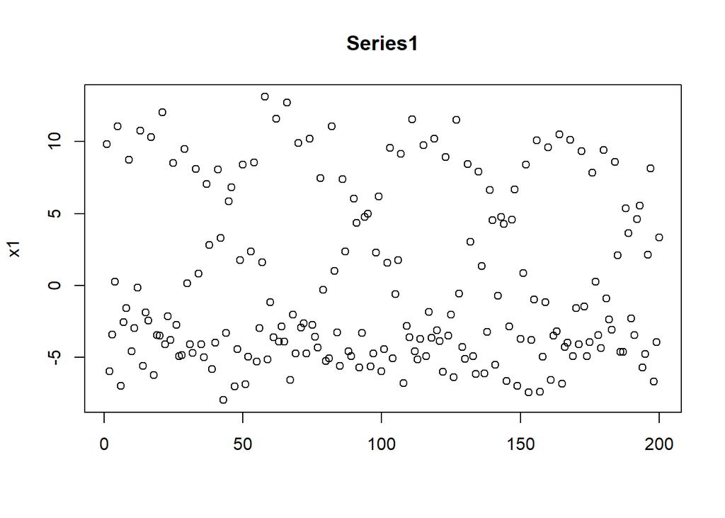

```r
x1 <- data[,1]
matplot(x1,type='p',main='Series1',pch=21)
```

Вычислить периодограмму данных выборки 1. По периодограмме определить 2 частоты гармонических колебаний, присутствующих в данных.

(Skipped Code)

```r
pgm<- periodogram(x1, col = "blue",lwd = 3,main = 'Series1. Periodogram',xlab='Frequency',ylab='Intensity',panel.first=grid(nx=NULL,ny = NULL))
```

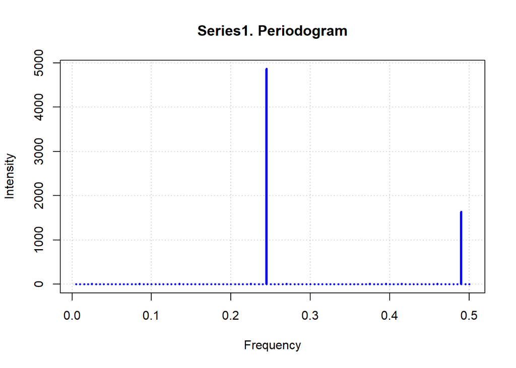

#### 2. Выборка Series2.

Исследовать ряд на предмет наличия Эхо эффекта. При наличии эха определить задержку и величину кепстра на задержке.

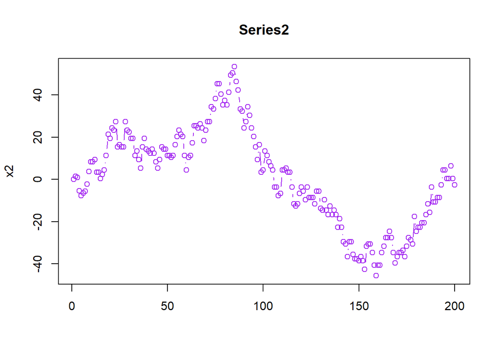

```r
x2 <- data[,2]
matplot(x2,type='b',main='Series2',pch=21,col='purple')
```

Ряд нестационарный, поэтому берем разности

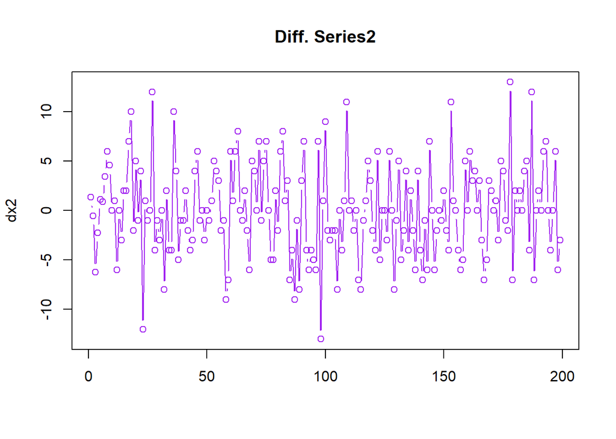

```r
dx2 <-diff(x2)
matplot(dx2,type='b',main='Diff. Series2',pch=21,col='purple')
```

Строим периодограмму для разностей

(Skipped Code)

```r
pgm<- periodogram(dx2, col = "blue",lwd = 3,main = 'Diff. Series2. Periodogram',xlab='Frequency',ylab='Intensity',panel.first=grid(nx=NULL,ny = NULL))
```

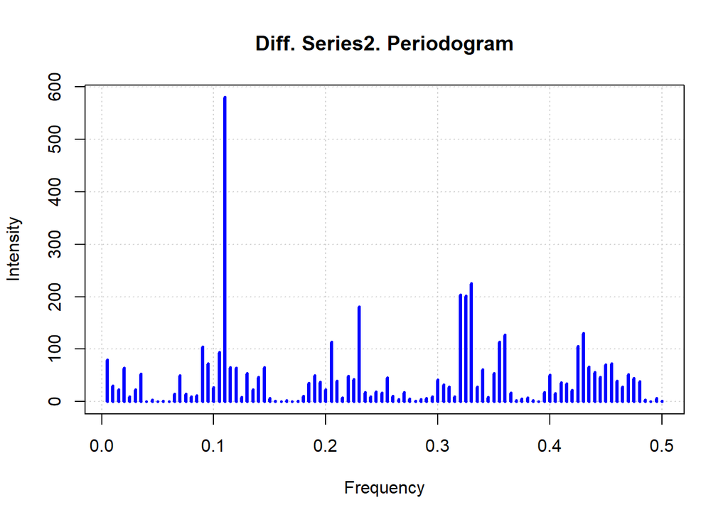

В периодограмме едва заметны косинусоидальные колебания. Они станут заметнее, если провести сглаживание по 3-х кратной свертке окна Даниелла ширины 7.